# EstimateCost

```python
%load_ext autoreload
%autoreload 2
%pdb 0
```

```python
import pandas as pd
import numpy as np
import csrar
from sklearn.model_selection import train_test_split
from sklearn.tree import DecisionTreeClassifier
from sklearn.ensemble import RandomForestClassifier, ExtraTreesClassifier
from sklearn import svm
```

```python
data = pd.read_csv('../data/Injector_Median100k.csv')
```

```python
import arff
file = open('../data/test5.arff', 'r')
dataset = arff.load(file)
data = pd.DataFrame(dataset['data'])
```

#### About test2.arff:

useful=Vector(0, 1)  
dependent=Vector(5, 6, 7, 8, 9)  
duplicated=Vector((0,12), (4,10), (6,11))  
nominal=List()  
clusters=[(0, 1, 2), (3, 4)]  
distribution=List(24860, 25140)  
seed=0

#### About test3.arff

useful=Vector(0, 1)  
dependent=Vector(5, 6, 7, 8, 9)  
duplicated=Vector((0,12), (4,10), (6,11))  
nominal=List()  
clusters=[(0, 1, 2), (3, 4)]  
distribution=List(249786, 250214)

#### About test4.arff

useful=Vector(0, 1, 2, 3, 4, 5, 6, 7, 8, 9, 10, 11, 12, 13, 14, 15, 16, 17, 18, 19, 20, 21, 22, 23, 24, 25, 26, 27, 28, 29)  
dependent=Vector(100, 101, 102, 103, 104, 105, 106, 107, 108, 109, 110, 111, 112, 113, 114, 115, 116, 117, 118, 119, 120, 121, 122, 123, 124, 125, 126, 127, 128, 129, 130, 131, 132, 133, 134, 135, 136, 137, 138, 139, 140, 141, 142, 143, 144, 145, 146, 147, 148, 149)  
duplicated=Vector((7,168), (10,157), (24,159), (28,162), (30,166), (50,169), (61,154), (82,158), (99,167), (104,156), (107,151), (113,164), (117,155), (117,165), (124,150), (135,160), (139,152), (145,161), (146,153), (147,163))  
nominal=List()  
clusters=[(0, 1, 2, 3, 4, 5, 6, 7, 8, 9), (10, 11, 12, 13, 14), (15, 16, 17)]  
distribution=List(250085, 249915)

#### About test5.arff

useful=Vector(0, 1, 2, 3, 4, 5, 6, 7, 8, 9)  
dependent=Vector(80, 81, 82, 83, 84, 85, 86, 87, 88, 89, 90, 91, 92, 93, 94, 95, 96, 97, 98, 99, 100, 101, 102, 103, 104, 105, 106, 107, 108, 109)  
duplicated=Vector((4,118), (8,114), (8,146), (9,137), (9,144), (10,131), (17,123), (22,116), (24,120), (24,142), (25,125), (35,127), (42,119), (43,122), (45,111), (48,134), (50,132), (52,110), (54,138), (57,112), (57,115), (57,149), (62,141), (64,136), (70,117), (70,148), (73,126), (76,133), (77,140), (78,143), (83,113), (84,139), (91,145), (92,121), (93,128), (93,135), (95,124), (103,129), (104,130), (105,147))  
nominal=List()  
clusters=[(0, 1, 2), (3, 4), (5, 6, 7, 8, 9, 10, 11, 12, 13, 14)]  
distribution=List(99718, 100282)

### Train/Test Split

```python
target = 150
X = data.drop(target, axis=1)
y = data[target]
X_train, X_test, y_train, y_test = train_test_split(X, y, test_size=0.2)
```

## RaR

```python
rar_data = pd.concat([X_train, y_train], axis=1)
# RaR uses columns with string label only
rar_data.rename(columns=lambda c: str(c), inplace=True)
target = str(target)
rar = csrar.rar.RaR(rar_data)
rar.run(target, k=5, runs=150, split_iterations=5)
```

```
Relevance: 99.33%     Running optimizer...
Optimizer done.
Redundancy: 99.33%     1. 7 with a score of 0.9999793745746006
2. 146 with a score of 0.762621607477301
3. 2 with a score of 0.3393327384440848
4. 97 with a score of 0.2505105138070438
5. 114 with a score of 0.14503952156131664
6. 128 with a score of 0.09293971571401534
7. 0 with a score of 0.07663044090938512
8. 45 with a score of 0.07663025773502889
9. 83 with a score of 0.06490842037779845
10. 25 with a score of 0.05263761556113386
11. 145 with a score of 0.052637427457499074
12. 91 with a score of 0.045885968683544526
13. 12 with a score of 0.04287280774404989
14. 137 with a score of 0.04269505754590634
15. 9 with a score of 0.04115382987918875
16. 105 with a score of 0.03721294150370557
17. 1 with a score of 0.03603461143661206
18. 124 with a score of 0.03150639820375944
19. 108 with a score of 0.031506385237732096
20. 31 with a score of 0.029569359242439815
21. 42 with a score of 0.029569344523583136
22. 101 with a score of 0.029332813564664023
23. 92 with a score of 0.027108472296199407
24. 5 with a score of 0.026361395340999766
25. 64 with a score of 0.022137323269970626
26. 130 with a score of 0.019223541763956603
27. 129 with a score of 0.018960211774269983
28. 98 with a score of 0.01597439170273491
29. 72 with a score of 0.015470601254609391
30. 136 with a score of 0.01547059822098925
31. 139 with a score of 0.013423541894177745
32. 30 with a score of 0.011199837178593863
33. 95 with a score of 0.006998254912109532
34. 100 with a score of 0.006613997040606196
35. 106 with a score of 0.006544235012387513
36. 87 with a score of 0.005533446648452412
37. 80 with a score of 0.005533446648452366
38. 76 with a score of 0.005530232381445322
```

[output cut: 97 more lines]

```
136. 119 with a score of 1.956112750822164e-11
137. 144 with a score of 1.956112750822164e-11
138. 18 with a score of 1.9561127508221635e-11
139. 96 with a score of 1.9561127508221635e-11
140. 99 with a score of 1.9561127508221635e-11
141. 102 with a score of 1.9561127508221635e-11
142. 147 with a score of 1.9561127508221635e-11
143. 24 with a score of 1.9561127508221632e-11
144. 140 with a score of 1.9561127508221632e-11
145. 65 with a score of 1.9561127508221622e-11
146. 135 with a score of 1.956112750822162e-11
147. 143 with a score of 1.956112750822162e-11
148. 85 with a score of 1.9561127508221606e-11
149. 16 with a score of 1.9561110415358824e-11
150. 59 with a score of 1.9561017568838653e-11
```

## DecisionTreeClassifier for Feature Ranking

```python
clf = DecisionTreeClassifier()
clf.fit(X_train, y_train)
clf.score(X_test, y_test)
```

```
0.75280000000000002
```

```python
ranking = []
for index, importance in enumerate(clf.feature_importances_):
    ranking.append((data.columns[index], importance))
ranking.sort(key=lambda r: r[1], reverse=True)
for (index, rank) in enumerate(ranking):
        print('{}. {} with a score of {}'.format(index + 1, rank[0], rank[1]))
```

```
1. 7 with a score of 0.17694237453303102
2. 2 with a score of 0.11648570562898031
3. 8 with a score of 0.07415892873442204
4. 6 with a score of 0.06520977393730461
5. 146 with a score of 0.06363040417609019
6. 5 with a score of 0.02856164791359312
7. 1 with a score of 0.024519399611556178
8. 114 with a score of 0.021521603752805877
9. 0 with a score of 0.016270707864219695
10. 9 with a score of 0.00868449383506931
11. 144 with a score of 0.007694073741676942
12. 137 with a score of 0.006505175530918664
13. 3 with a score of 0.005366753158516964
14. 16 with a score of 0.004499675004896028
15. 66 with a score of 0.004329319951858237
16. 15 with a score of 0.004166952631363055
17. 67 with a score of 0.004154227402608276
18. 29 with a score of 0.0041439720280645785
19. 14 with a score of 0.004121189188914769
20. 36 with a score of 0.004048043647259687
21. 13 with a score of 0.003957809580735234
22. 108 with a score of 0.003950693358172197
23. 81 with a score of 0.00391310490632256
24. 56 with a score of 0.0038576580217654045
25. 69 with a score of 0.003830769298136401
26. 19 with a score of 0.003825563412814371
27. 30 with a score of 0.0038163207402581644
28. 109 with a score of 0.0038094955047995238
29. 27 with a score of 0.00379475198112429
30. 80 with a score of 0.003770782337443727
31. 101 with a score of 0.0037452470906444994
32. 102 with a score of 0.003732649123315862
33. 23 with a score of 0.0037104407870860007
34. 58 with a score of 0.0037016725519550516
35. 65 with a score of 0.0037016686468622955
36. 31 with a score of 0.0036951036584887934
37. 94 with a score of 0.003689654043109988
38. 75 with a score of 0.003663761355010861
39. 44 with a score of 0.00362072297523777
40. 34 with a score of 0.0036164555312085686
```

[output cut: 95 more lines]

```
136. 148 with a score of 0.0018178915878179366
137. 105 with a score of 0.001777859115549354
138. 121 with a score of 0.001775548906550007
139. 70 with a score of 0.0017718178090134708
140. 145 with a score of 0.0017410397051372743
141. 134 with a score of 0.0016784541580566839
142. 91 with a score of 0.001666984738393387
143. 57 with a score of 0.0015465636027910412
144. 117 with a score of 0.0015174695385421783
145. 128 with a score of 0.0013834292922005403
146. 120 with a score of 0.001337365971760384
147. 149 with a score of 0.0013299280156774452
148. 24 with a score of 0.0011201709704210467
149. 112 with a score of 0.0011133356895528686
150. 115 with a score of 0.000954328155915234
```

## Benchmarking with top k features

```python
import sys

clf_selected = RandomForestClassifier()
scores = pd.DataFrame(columns=['RaR', 'DecisionTree'], index=np.arange(40))
scores = scores.fillna(0)
max_k = 40

# RaR
for i in range(1,max_k):
    selected_features = list(map(lambda f: int(f[0]), rar.feature_ranking[:i]))
    X_train_s = X_train[selected_features]
    X_test_s = X_test[selected_features]
    clf_selected.fit(X_train_s, y_train)
    scores.loc[i, 'RaR'] = clf_selected.score(X_test_s, y_test)
    sys.stdout.write('\rBenchmark: {}%     '.format(100 * i / (2*max_k)))
    sys.stdout.flush()

# ExtraTrees
for i in range(1,max_k):
    selected_features = [r[0] for r in ranking[:i]]
    X_train_s = X_train[selected_features]
    X_test_s = X_test[selected_features]
    clf_selected.fit(X_train_s, y_train)
    scores.loc[i, 'DecisionTree'] = clf_selected.score(X_test_s, y_test)
    sys.stdout.write('\rBenchmark: {}%     '.format(50 + 100 * i / (2*max_k)))
    sys.stdout.flush()
print('Benchmark: 100.0%')
```

[output not shown]

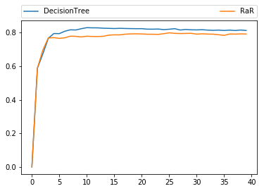

```python
import matplotlib.pyplot as plt
plt.plot(scores['DecisionTree'], label='DecisionTree')
plt.plot(scores['RaR'], label='RaR')
plt.legend(bbox_to_anchor=(0., 1.02, 1., .102), loc=3,
           ncol=2, mode="expand", borderaxespad=0.)
plt.savefig('test4_FS_RandomForest_Score')
plt.show()
```

## Other

```python
# In case we need to look at the tree
from sklearn import tree
import pydot
from sklearn.externals.six import StringIO
dot_data = StringIO()
tree.export_graphviz(clf, out_file='tree.dot')
```